Estadística 1 | 2020

[figure not shown]

# Guía de Clase del TP6: Inferencia en dos muestras

Docentes: Patricia M. Acetta y Agustin Alesso

# Objetivos

En la unidad 5, se explicaron métodos para tratar una muestra de una población. En esta unidad se extienden esos métodos a situaciones que involucran a dos poblaciones. Los objetivo del este TP son:

- Distinguir entre dos muestras de poblaciones independientes o dependientes
- Estimar el intervalo de confianza sobre dos parámetros poblacionales ($\mu_1 - \mu_2$, $\sigma^2_1/\sigma^2_2$, $\pi_1- \pi_2$) a partir de muestras aleatorias.
- Realizar pruebas de hipótesis sobre dos parámetros poblacionales ($\mu_1 - \mu_2$, $\sigma^2_1/\sigma^2_2$, $\pi_1- \pi_2$) a partir de muestras aleatorias.

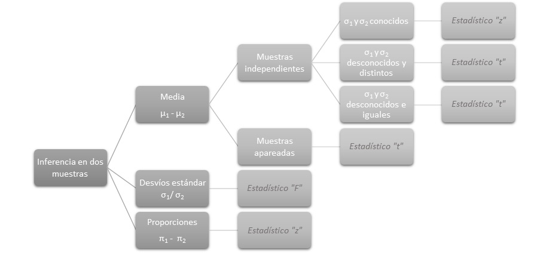

# Inferencia en dos medias

## Repaso

**Hipótesis posibles:**

$$H_0: \mu_1 - \mu_2 = 0 \quad \text{vs} \quad H_1: \mu_1 - \mu_2 \ne 0 \\
H_0: \mu_1 - \mu_2 \le 0 \quad \text{vs} \quad H_1: \mu_1 - \mu_2 > 0 \\
H_0: \mu_1 - \mu_2 \ge 0 \quad \text{vs} \quad H_1: \mu_1 - \mu_2 < 0$$

**¿Muestras dependientes o independientes?**

Dos muestras son **independientes** si los valores muestrales de una población no están relacionados o de alguna manera naturalmente emparejados o combinados con los valores muestrales de otra población.

En cambio, son **dependientes** (pares relacionados) si los valores muestrales se corresponden de alguna manera ya sea por una relación inherente (observaciones en el mismo sujeto o sitio, como datos de antes y después, o cada par de valores muestrales consiste en pares coincidentes, donde la coincidencia se basa en alguna relación significativa).

**Aclaración:** Si las dos muestras tienen diferentes tamaños de muestra sin datos faltantes, deben ser independientes. Si las dos muestras tienen el mismo tamaño de muestra, las muestras pueden ser independientes o no.

# Inferencia en dos medias muestras independientes, $\sigma_1$ y $\sigma_2$ conocidos

El estimador de la diferencia $\mu_1 - \mu_2$ sigue una distribución:

$$\bar{X}_1 - \bar{X}_2 \sim N \left( \mu_1 - \mu_2, \sqrt{\dfrac{\sigma_1^2}{n_1} + \dfrac{\sigma_2^2}{n_2}}\right)$$

#### Intervalo de confianza

$$\small
P \left[ (\bar{X}_1 - \bar{X}_2) + Z_{\alpha/2} \left(\sqrt{\dfrac{\sigma_1^2}{n_1} + \dfrac{\sigma_2^2}{n_2}} \right) \leq \mu_1 - \mu_2 \leq (\bar{X}_1 - \bar{X}_2) + Z_{1-\alpha/2} \left(\sqrt{\dfrac{\sigma_1^2}{n_1} + \dfrac{\sigma_2^2}{n_2}} \right) \right] = 1 - \alpha$$

#### Prueba de Hipótesis

**Estadístico de prueba:**

$$Z = \dfrac{(\bar{X}_1 - \bar{X}_2) - (\mu_1 - \mu_2)}{\sqrt{\dfrac{\sigma^2_1}{n_1} + \dfrac{\sigma^2_2}{n_2}}} \sim N (0,1)$$

# Ejercicio 1

Continuando con el ejercicio 1 de la Guía de Clase de TP5.

El productor de apio compara el registro de largo de cosecha de las plantas de la última campaña 2019 con los datos de la campaña 2018, los resultados de la campaña 2018, están en el archivo `apios2.xlsx`, los datos de la última campaña 2019 están en el archivo `apios.xlsx`.

Recordar que los apios deben cosecharse con una altura de 75 cm y un desvío de 10 cm, para que la producción mantenga su rentabilidad. Diferecias en ese tamaño, disminuyen la rentabilidad y las características cualitativas del cultivo.

**Responder:**

1. ¿Cuál es la estimación puntual de la diferencia de longitud media de los apios de las campañas 2018 y 2019?
2. ¿Cuáles son los límites de confianza del 99% de la diferencia de longitud media de los apios de las campañas 2018 y 2019?
3. Pruebe la hipótesis de que la longitud media de los apios cosechados en ambas campañas fue similar. Utilice un nivel de significancia de 0.01.

Importamos los datos:

```r
library(readxl)
apios2018 <- read_xlsx("apios2.xlsx")
apios2019 <- read_xlsx("apios.xlsx")
```

## Item (a).

**¿Cuál es la estimación puntual de la diferencia de longitud media de los apios de las campañas 2018 y 2019?**

```r
dif_xbar <- mean(apios2018$Largo)-mean(apios2019$Largo)
dif_xbar
```

```
[1] -1.217907
```

*Respuesta:* La estimación puntual de la diferencia de longitud media de los apios es de -1.22 cm. Esto indica que los apios cosechados en 2018 en promedio eran mas cortos que los cosechados en 2019 (signo negativo).

## Item (b).

**¿Cuáles son los límites de confianza del 99% de la diferencia de longitud media de los apios de las campañas 2018 y 2019?**

Queremos obtener: $P(LI \le \mu_\text{2018} - \mu_\text{2019} \le LS)=99\text{%}$, donde LI: límite inferior y LS: límite superior.

En este ejercicio, asumiremos que los desvíos poblacionales $\sigma_2018$ y $\sigma_2019$ son conocidos e iguales y su valor es: 10 cm para ambas poblaciones, por lo tanto seguiremos el procedimiento de cálculo con el estadístico “z”.

Podemos hacerlo de varias maneras:

Alternativa 1: calculando por separado las partes de un IC

```r
dif_xbar
```

```
[1] -1.217907
```

```r
alfa <- 0.01                 # 1 - 0.99 = 0.01

n18 <- length(apios2018$Largo)
xbar18 <- mean(apios2018$Largo)
sigma18 <- 10

n19 <- length(apios2019$Largo)
xbar19 <- mean(apios2019$Largo)
sigma19 <- 10

# valores críticos de la distribución normal: alfa se divide por 2 porque busco los dos extremos de la distribución
zcrit <- qnorm(c(alfa/2, 1-alfa/2))

# error estándar de la diferencia
error <- sqrt(sigma18^2/n18 + sigma19^2/n19)

# Margen de error: valor crítico * error estándar
ME <- zcrit * error

# IC99%  = EP +- ME

IC <- dif_xbar + ME
IC
```

```
[1] -2.1842401 -0.2515733
```

Alternativa 2: utilizando la función `ZTest()` del paquete `DescTools`

```r
library(DescTools)
ZTest<- ZTest(x = apios2018$Largo, y = apios2019$Largo,alternative = "two", sd_pop = 10, conf.level = 0.99)

ZTest
```

```
    Two Sample z-test

data:  apios2018$Largo and apios2019$Largo
z = -3.2464, Std. Dev. Population = 10, p-value = 0.001169
alternative hypothesis: true difference in means is not equal to 0
99 percent confidence interval:
 -2.1842401 -0.2515733
sample estimates:
mean of x mean of y
 74.67007  75.88797
```

- `x`: datos de la primer muestra
- `y`: datos de la segunda muestra
- `alternative`: para IC siempre es “two”, que significa a ambos lados de la curva
- `sd_pop`: es el desvío que ya conocemos de la población $\sigma$
- `conf.level`: indica el nivel de confianza (NO significancia), por defecto el 0.95 (o 95%)

*Aclaración:* `ZTest()` sólo se puede usar cuando $\sigma_1 = \sigma_2$, de lo contrario No se puede utilizar.

*Respuesta:* De ambas maneras podemos observar que el Límite Inferior es de -2.1842401 cm y el Límite Superior es de -0.2515733 cm del Intervalo de Confianza del 99% de la diferencia de longitud media de los apios de las campañas 2018 y 2019.

## Item (c).

**Pruebe la hipótesis de que la longitud media de los apios cosechados en ambas campañas fue similar. Utilice un nivel de significancia de 0.01.**

*Prestar atención al orden: quién ponemos primero en los cálculos (datos de la muestra 2018 o 2019)*

*Seguiremos los pasos de una PH:*

1. Definir las hipótesis

$H_0: \mu_\text{2018} = \mu_\text{2019}$

$H_1: \mu_\text{2018} \ne \mu_\text{2019}$

2. Determinar el valor del estadístico de prueba

El estadístico de prueba es: $Z = \dfrac{(\bar{X}_1 - \bar{X}_2) - (\mu_1 - \mu_2)}{\sqrt{\dfrac{\sigma^2_1}{n_1} + \dfrac{\sigma^2_2}{n_2}}} \sim N (0,1)$

```r
z_calc <- (xbar18 - xbar19)/ sqrt(sigma18^2/n18 + sigma19^2/n19)
z_calc
```

```
[1] -3.246415
```

3. Determinar de la distribución muestral que se utilizará para la prueba de hipótesis

Continuaremos con la Distribución normal o $Z \sim N(0,1)$, dado que el desvio poblacional $\sigma$ es conocido = 10 cm para ambas poblaciones.

4. Identificación de un valor $p$ y/o el(los) valor(es) crítico(s)

En función de la distribución determinada en el paso anterior, buscaremos los valores críticos ya que es una prueba **bilateral** como lo determina la $H_1$ con el símbolo $\ne$.

Alternativa 1: calculando por separado las partes de una PH

Tomando decisión a través de los valores críticos:

```r
alfa <- 0.01
z_crit <- qnorm(p = c(alfa/2, 1- alfa/2))
# alfa se divide por dos porque la prueba es bilateral

z_crit
```

```
[1] -2.575829  2.575829
```

[output not shown]

[output not shown]

[output not shown]

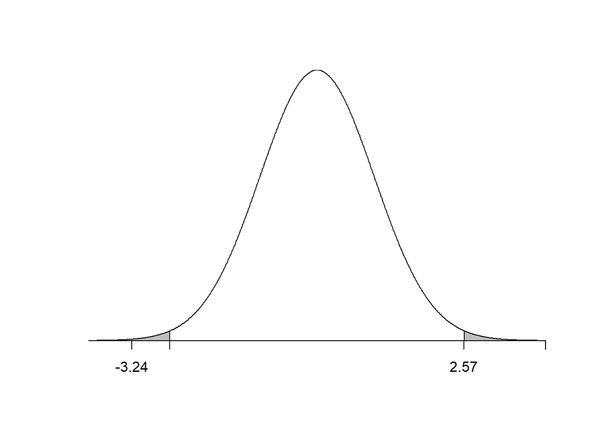

*El área gris corresponde a la región de rechazo, el estadistico de prueba o calculado, -3.2464154, cae en Zona de Rechazo*

Tomando decisión a través del valor $p$:

```r
pvalue <- pnorm(z_calc, lower.tail = z_calc < 0) * 2
# se multipla por 2 porque la prueba es bilateral
pvalue
```

```
[1] 0.001168682
```

Alternativa 2: utilizando la función `ZTest()` del paquete `DescTools`

```r
library(DescTools)

ZTest<- ZTest(x = apios2018$Largo, y = apios2019$Largo, alternative = "two", sd_pop = 10)

ZTest
```

```
    Two Sample z-test

data:  apios2018$Largo and apios2019$Largo
z = -3.2464, Std. Dev. Population = 10, p-value = 0.001169
alternative hypothesis: true difference in means is not equal to 0
95 percent confidence interval:
 -1.9531956 -0.4826178
sample estimates:
mean of x mean of y
 74.67007  75.88797
```

- `x`: son los datos con los cuales haremos inferencia
- `alternative`: en PH lo determina el signo de $H_1$
- `mu` es el valor de la media poblacional que estoy contrastando en las hipótesis
- `sd_pop`: es el desvío que ya conocemos de la población $\sigma$
- `conf.level`: indica el nivel de confianza (NO significancia)

**Aclaraciones**:

- **en ninguna parte de la Alternativa 2, se especifica el $\alpha$ o nivel de significancia, ya que lo que hacemos es tomar el valor $p$ de la salida y lo comparamos con el $\alpha$ que nos indique la consigna**
- **`ZTest()` sólo se puede usar cuando $\sigma_1 = \sigma_2$, de lo contrario No se puede utilizar.**
5. Conclusión COMPLETA:
- Si concluyo con los valores críticos:

Existe evidencia suficiente para rechazar la $H_0$, ya que el estadístico de prueba se encuentra en la región de rechazo, por lo tanto no podemos afirmar que los largos a los cuales se cosecho en las campañas 2018 y 2019 sean iguales.

- Si concluyo con el valor $p$:

Existe evidencia suficiente para rechazar la $H_0$, ya que el valor $p$ (0.0011687) es menor al nivel de significancia ($\alpha$), por lo tanto no podemos afirmar que los largos a los cuales se cosecho en las campañas 2018 y 2019 sean iguales.

# Inferencia en dos medias: muestras independientes, $\sigma_1$ y $\sigma_2$ desconocidos e iguales

Se reemplaza $\sigma_1^2$ y $\sigma_2^2$ por una estimación que resulta de promediar las **varianzas muestrales**, ponderando por sus grados de libertad, y se llama **varianza amalgamada** $(s_a^2)$.

$$s_a^2 = \dfrac{(n_1 - 1) s^2_1 + (n_2 - 1) s^2_2}{n_1 + n_2 - 2}$$

### Intervalo de confianza

$$\small
P \left[ (\bar{X}_1 - \bar{X}_2) + t_{\alpha/2, n_1+n_2-2} s_a \sqrt{\dfrac{1}{n_1} + \dfrac{1}{n_2}} \leq \mu_1 - \mu_2 \leq (\bar{X}_1 - \bar{X}_2) + t_{1-\alpha/2, n_1+n_2-2} s_a \sqrt{\dfrac{1}{n_1} + \dfrac{1}{n_2}} \right] = 1 - \alpha$$

### Prueba de Hipótesis

**Estadístico de prueba:**

$$t = \dfrac{(\bar{X}_1 - \bar{X}_2) - (\mu_1 - \mu_2)}{s_a \sqrt{\dfrac{1}{n_1} + \dfrac{1}{n_2}}} \sim t_{n_1 + n_2 -2}$$

donde: $s_a$ es la raíz cuadrada de la **varianza amalgamada**

$$s_a^2 = \dfrac{(n_1 - 1) s^2_1 + (n_2 - 1) s^2_2}{n_1 + n_2 - 2}$$

# Ejercicio 2

**Responder:**

1. ¿Cuál es la estimación puntual de la diferencia del peso medio de empaque del herbicida de los dos meses analizados?
2. ¿Cuáles son los límites de confianza del 90% de la diferencia de peso de empaque del herbicida de los dos meses analizados?
3. Se sospecha que en el mes de enero el peso medio de los envases fue mayor a los de febrero por un defecto en la maquina ¿Existe evidencia que indique esto?. Utilice un nivel de significancia de 0.05.

En este ejercicio, asumiremos que los desvíos poblacionales $\sigma_\text{enero}$ y $\sigma_\text{ferbero}$ son desconocidos y se asumen **iguales**, por lo tanto seguiremos el procedimiento de cálculo con el estadístico “t”, en donde se reemplaza $\sigma_1^2$ y $\sigma_2^2$ por una estimación que resulta de promediar las **varianzas muestrales**, ponderando por sus grados de libertad, y se llama **varianza amalgamada** $(s_a^2)$.

$$s_a^2 = \dfrac{(n_1 - 1) s^2_1 + (n_2 - 1) s^2_2}{n_1 + n_2 - 2}$$

Importamos los datos:

```r
library(readxl)
glifo_febrero <- read_xlsx("glifosato.xlsx")
glifo_enero <- read_xlsx("glifosato2.xlsx")
```

*Respetar el orden de las muestras, por ejemplo, primero “enero” y luego “febrero”.*

## Item (a).

**¿Cuál es la estimación puntual de la diferencia del peso medio de empaque del herbicida de los dos meses analizados?**

```r
dif_xbar <- mean(glifo_enero$Peso)-mean(glifo_febrero$Peso)
dif_xbar
```

```
[1] 0.006404615
```

*Respuesta:* La estimación puntual de la diferencia el peso medio de empaque del herbicida de los dos meses analizados es de 0.01 cm.

## Item (b).

**¿Cuáles son los límites de confianza del 90% de la diferencia de peso de empaque del herbicida de los dos meses analizados?**

Queremos obtener: $P(LI \le \mu_\text{enero} - \mu_\text{febrero} \le LS)=90\text{%}$, donde LI: límite inferior y LS: límite superior.

Podemos hacerlo de varias maneras:

Alternativa 1: calculando por separado las partes de un IC

```r
dif_xbar
```

```
[1] 0.006404615
```

```r
alfa <- 0.1                 # 1 - 0.90 = 0.1

n_ene <- length(glifo_enero$Peso)
xbar_ene <- mean(glifo_enero$Peso)
s_ene <- sd(glifo_enero$Peso)

n_feb <- length(glifo_febrero$Peso)
xbar_feb <- mean(glifo_febrero$Peso)
s_feb<- sd(glifo_febrero$Peso)

# valores críticos de la distribución t: alfa se divide por 2 porque busco los dos extremos de la distribución
tcrit <- qt(c(alfa/2, 1-alfa/2), df = n_ene+n_feb-2)

# S amalgamada
s2_a <- weighted.mean(x = c(s_ene^2, s_feb^2), w = c(n_ene-1, n_feb-1))
s_a <- sqrt(s2_a)

# error estándar
error <-  s_a * sqrt(1/n_ene + 1/n_feb)

# Margen de error: valor crítico * error estándar
ME <- tcrit * error

# IC90%  = EP +- ME
IC <- dif_xbar + ME
IC
```

```
[1] -0.001238191  0.014047422
```

Alternativa 2: utilizando la función `t.test()` del paquete base de R

```r
ttest<- t.test(x = glifo_enero$Peso, y = glifo_febrero$Peso, alternative = "two", var.equal = T, conf.level = 0.90)

ttest
```

```
    Two Sample t-test

data:  glifo_enero$Peso and glifo_febrero$Peso
t = 1.3795, df = 1148, p-value = 0.168
alternative hypothesis: true difference in means is not equal to 0
90 percent confidence interval:
 -0.001238191  0.014047422
sample estimates:
mean of x mean of y
 15.00238  14.99598
```

- `x`: datos de la primer muestra
- `y`: datos de la segunda muestra
- `alternative`: para IC siempre es “two”, que significa a ambos lados de la curva
- `conf.level`: indica el nivel de confianza (NO significancia), por defecto el 0.95 (o 95%)
- `var.equal`: para indicar si las varianzas son homogéneas o no.

*Respuesta:* De ambas maneras podemos observar que el Límite Inferior es de -0.0012382 kg y el Límite Superior es de 0.0140474 kg del Intervalo de Confianza del 90% de la diferencia de peso de empaque del herbicida de los dos meses analizados.

$$P(-0.0012382 \le \mu_\text{enero} - \mu_\text{febrero} \le 0.0140474)=90\text{%}$$

## Item (c).

**Se sospecha que en el mes de enero el peso medio de los envases fue mayor a los de febrero por un defecto en la maquina ¿Existe evidencia que indique esto?. Utilice un nivel de significancia de 0.05.**

*Prestar atención al orden: quién ponemos primero en los cálculos (datos de la muestra enero o febrero)*

*Seguiremos los pasos de una PH:*

1. Definir las hipótesis

$H_0: \mu_\text{enero} \le \mu_\text{febrero}$

$H_1: \mu_\text{enero} > \mu_\text{febrero}$

2. Determinar el valor del estadístico de prueba

El estadístico de prueba es: $t = \dfrac{(\bar{X}_1 - \bar{X}_2) - (\mu_1 - \mu_2)}{s_a \sqrt{\dfrac{1}{n_1} + \dfrac{1}{n_2}}}$

Se reemplaza $\sigma_1^2$ y $\sigma_2^2$ por una estimación que resulta de promediar las **varianzas muestrales**, ponderando por sus grados de libertad, y se llama **varianza amalgamada** $(s_a^2)$.

$$s_a^2 = \dfrac{(n_1 - 1) s^2_1 + (n_2 - 1) s^2_2}{n_1 + n_2 - 2}$$

```r
# S amalgamada
s2_a <- weighted.mean(x = c(s_ene^2, s_feb^2), w = c(n_ene-1, n_feb-1))
s_a <- sqrt(s2_a)

# estadístico de prueba
t_calc <- (xbar_ene - xbar_feb)/ (s_a * sqrt(1/n_ene + 1/n_feb))
t_calc
```

```
[1] 1.379488
```

3. Determinar de la distribución muestral que se utilizará para la prueba de hipótesis

Continuaremos con la Distribución $t \sim t_{n_1 + n_2 -2}$, dado que los desvios poblacionales son desconocidos.

4. Identificación de un valor $p$ y/o el(los) valor(es) crítico(s)

En función de la distribución determinada en el paso anterior, buscaremos los valores críticos ya que es una prueba **unilateral** como lo determina la $H_1$ con el símbolo $>$.

Alternativa 1: calculando por separado las partes de una PH

Tomando decisión a través de los valores críticos:

```r
alfa <- 0.05
t_crit <- qt(alfa, df = n_ene + n_feb - 2, lower.tail = F)
# lower.tail = F, por que la H1 tiene el simbolo >
t_crit
```

```
[1] 1.646182
```

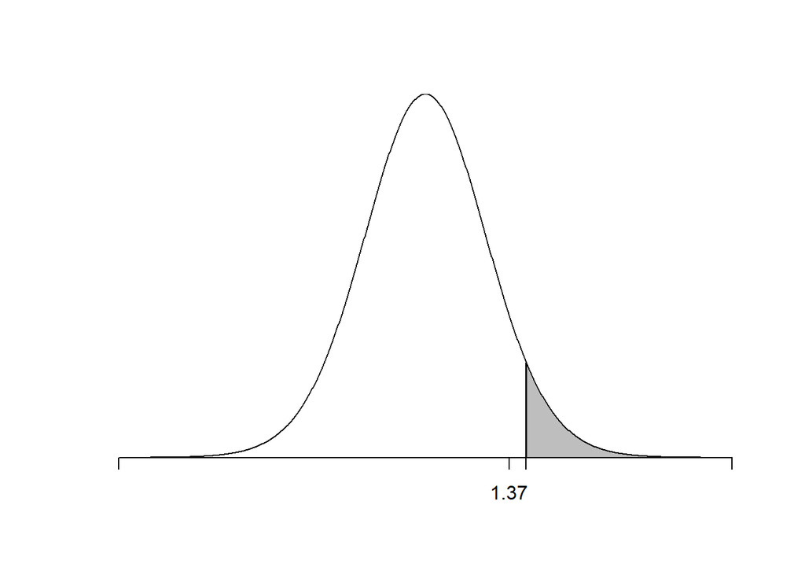

*El área gris corresponde a la región de rechazo (área a la derecha del valor crítico 1.646182 ya que $H_1$ tiene el símbolo $>$), el estadistico de prueba o calculado 1.3794884, cae en Zona de NO Rechazo*

Tomando decisión a través del valor $p$:

```r
pvalue <- pt(t_calc, df = n_ene + n_feb - 2, lower.tail = F)
# lower.tail = F, por que la H1 tiene el simbolo >

pvalue
```

```
[1] 0.08400643
```

Alternativa 2: utilizando la función `t.test()` del paquete base de R

```r
ttest<- t.test(x = glifo_enero$Peso, y = glifo_febrero$Peso, alternative = "greater", var.equal = T)

ttest
```

```
    Two Sample t-test

data:  glifo_enero$Peso and glifo_febrero$Peso
t = 1.3795, df = 1148, p-value = 0.08401
alternative hypothesis: true difference in means is greater than 0
95 percent confidence interval:
 -0.001238191          Inf
sample estimates:
mean of x mean of y
 15.00238  14.99598
```

- `x`: datos de la primer muestra
- `y`: datos de la segunda muestra
- `alternative`: signo de la hipótesis alternativa, en este caso $>$: “greater”
- `var.equal`: para indicar si las varianzas son homogéneas o no.

**Aclaración:** en ninguna parte de la Alternativa 2, se especifica el $\alpha$ o nivel de significancia, ya que lo que hacemos es tomar el valor $p$ de la salida y lo comparamos con el $\alpha$ que nos indique la consigna.

5. Conclusión COMPLETA:
- Si concluyo con los valores críticos:

No existe evidencia suficiente para rechazar la $H_0$, ya que el estadístico de prueba se encuentra en la región de no rechazo, por lo tanto podemos afirmar que el peso medio de los envases en enero no fue mayor que en febrero.

- Si concluyo con el valor $p$:

No existe evidencia suficiente para rechazar la $H_0$, ya que el valor $p$ (0.0840064) es mayor al nivel de significancia ($\alpha$), por lo tanto podemos afirmar que el peso medio de los envases en enero no fue mayor que en febrero.

# Inferencia en dos medias: muestras independientes, $\sigma_1$ y $\sigma_2$ desconocidos y distintos

Se reemplaza $\sigma^2_1$ y $\sigma^2_2$ por las varianzas muestrales $s^2_1$ y $s^2_2$ y se obtiene un estadísico $t$

$$t = \dfrac{(\bar{X}_1 - \bar{X}_2) - (\mu_1 - \mu_2)}{\sqrt{\dfrac{s^2_1}{n_1} + \dfrac{s^2_2}{n_2}}} \sim t_\delta$$

Donde $\delta$ se aproxima por la ecuación de Welch-Satterthwaite:

$$\delta =
\dfrac{ \left(\dfrac{s^2_1}{n_1} + \dfrac{s^2_2}{n_2} \right)^2}
{\left(\dfrac{s^2_1}{n_1}\right)^2 \dfrac{1}{n_1-1} +
\left(\dfrac{s^2_2}{n_2}\right)^2 \dfrac{1}{n_2-1}}$$

### Intervalo de confianza

$$P \left( \bar{X_d} + t_{\alpha/2, n_d-1} \dfrac{s_d}{\sqrt{n_d}} \leq \mu_d \leq \bar{X_d} + t_{1-\alpha/2, n_d-1} \dfrac{s_d}{\sqrt{n_d}} \right) = 1 - \alpha$$

### Prueba de Hipótesis

**Estadístico de prueba:**

$$t = \dfrac{(\bar{X}_1 - \bar{X}_2) - (\mu_1 - \mu_2)}{\sqrt{\dfrac{s_1^2}{n_1} + \dfrac{s^2_2}{n_2}}} \sim t_{\delta}$$

# Ejercicio 3

Continuando con el ejercicio 2 de esta Guía (continua el ejercicio 4 de la Guía de Clase de TP5). Una marca comercial conocida, dispende Glifosato en gránulos solubles, y cada paquete contiene 15 kg. Se registran los pesos del empaque durante todo el mes de febrero en la empresa (en el archivo `glifosato.xlsx`) y luego se los compara con los del mes anterior enero (en el archivo `glifosato2.xlsx`)

**Responder:**

1. ¿Cuál es la estimación puntual de la diferencia del peso medio de empaque del herbicida de los dos meses analizados?
2. ¿Cuáles son los límites de confianza del 90% de la diferencia de peso de empaque del herbicida de los dos meses analizados?
3. Se sospecha que en el mes de enero el peso medio de los envases fue mayor a los de febrero por un defecto en la maquina ¿Existe evidencia que indique esto?. Utilice un nivel de significancia de 0.05.

En este ejercicio, asumiremos que los desvíos poblacionales $\sigma_\text{enero}$ y $\sigma_\text{ferbero}$ son desconocidos y se asumen **distintos**, por lo tanto seguiremos el procedimiento de cálculo con el estadístico “t”, en donde se reemplaza $\sigma^2_1$ y $\sigma^2_2$ por las varianzas muestrales $s^2_1$ y $s^2_2$ y se obtiene un estadísico $t$

$$t = \dfrac{(\bar{X}_1 - \bar{X}_2) - (\mu_1 - \mu_2)}{\sqrt{\dfrac{s^2_1}{n_1} + \dfrac{s^2_2}{n_2}}} \sim t_\delta$$

Donde $\delta$ se aproxima por la ecuación de Welch-Satterthwaite:

$$\delta =
\dfrac{ \left(\dfrac{s^2_1}{n_1} + \dfrac{s^2_2}{n_2} \right)^2}
{\left(\dfrac{s^2_1}{n_1}\right)^2 \dfrac{1}{n_1-1} +
\left(\dfrac{s^2_2}{n_2}\right)^2 \dfrac{1}{n_2-1}}$$

Importamos los datos:

```r
library(readxl)
glifo_febrero <- read_xlsx("glifosato.xlsx")
glifo_enero <- read_xlsx("glifosato2.xlsx")
```

*Respetar el orden de las muestras, por ejemplo, primero “enero” y luego “febrero”.*

## Item (a).

**¿Cuál es la estimación puntual de la diferencia del peso medio de empaque del herbicida de los dos meses analizados?**

```r
dif_xbar <- mean(glifo_enero$Peso)-mean(glifo_febrero$Peso)
dif_xbar
```

```
[1] 0.006404615
```

*Respuesta:* La estimación puntual de la diferencia el peso medio de empaque del herbicida de los dos meses analizados es de 0.01 cm.

## Item (b).

**¿Cuáles son los límites de confianza del 90% de la diferencia de peso de empaque del herbicida de los dos meses analizados?**

Queremos obtener: $P(LI \le \mu_\text{enero} - \mu_\text{febrero} \le LS)=90\text{%}$, donde LI: límite inferior y LS: límite superior.

Podemos hacerlo de varias maneras:

Alternativa 1: calculando por separado las partes de un IC

```r
dif_xbar
```

```
[1] 0.006404615
```

```r
alfa <- 0.1                 # 1 - 0.90 = 0.1

n_ene <- length(glifo_enero$Peso)
xbar_ene <- mean(glifo_enero$Peso)
s_ene <- sd(glifo_enero$Peso)

n_feb <- length(glifo_febrero$Peso)
xbar_feb <- mean(glifo_febrero$Peso)
s_feb<- sd(glifo_febrero$Peso)

# valores críticos de la distribución t
delta <- ((s_ene^2/n_ene + s_feb^2/n_feb)^2) / (((s_ene^2/n_ene)^2)/(n_ene-1) + ((s_feb^2/n_feb)^2)/(n_feb-1))
delta
```

```
[1] 1084.127
```

```r
tcrit <- qt(c(alfa/2, 1-alfa/2), df = delta)

# error estándar
error <- sqrt(s_ene^2/n_ene + s_feb^2/n_feb)

# Margen de error: valor crítico * error estándar
ME <- tcrit * error

# IC90%  = EP +- ME
IC <- dif_xbar + ME
IC
```

```
[1] -0.00121788  0.01402711
```

Alternativa 2: utilizando la función `t.test()` del paquete base de R

```r
ttest<- t.test(x = glifo_enero$Peso, y = glifo_febrero$Peso, alternative = "two", var.equal = F, conf.level = 0.90)
ttest
```

```
    Welch Two Sample t-test

data:  glifo_enero$Peso and glifo_febrero$Peso
t = 1.3832, df = 1084.1, p-value = 0.1669
alternative hypothesis: true difference in means is not equal to 0
90 percent confidence interval:
 -0.00121788  0.01402711
sample estimates:
mean of x mean of y
 15.00238  14.99598
```

- `x`: datos de la primer muestra
- `y`: datos de la segunda muestra
- `alternative`: para IC siempre es “two”, que significa a ambos lados de la curva
- `conf.level`: indica el nivel de confianza (NO significancia), por defecto el 0.95 (o 95%)
- `var.equal`: para indicar si las varianzas son homogéneas o no.

*Respuesta:* De ambas maneras podemos observar que el Límite Inferior es de -0.0012179 kg y el Límite Superior es de 0.0140271 kg del Intervalo de Confianza del 90% de la diferencia de peso de empaque del herbicida de los dos meses analizados.

$$P(-0.0012179 \le \mu_\text{enero} - \mu_\text{febrero} \le 0.0140271)=90\text{%}$$

## Item (c).

**Se sospecha que en el mes de enero el peso medio de los envases fue mayor a los de febrero por un defecto en la maquina ¿Existe evidencia que indique esto?. Utilice un nivel de significancia de 0.05.**

*Prestar atención al orden: quién ponemos primero en los cálculos (datos de la muestra enero o febrero)*

*Seguiremos los pasos de una PH:*

1. Definir las hipótesis

$H_0: \mu_\text{enero} \le \mu_\text{febrero}$

$H_1: \mu_\text{enero} > \mu_\text{febrero}$

2. Determinar el valor del estadístico de prueba

El estadístico de prueba es: $t = \dfrac{(\bar{X}_1 - \bar{X}_2) - (\mu_1 - \mu_2)}{ \sqrt{\dfrac{S_1^2}{n_1} + \dfrac{S_2^2}{n_2}}}$

```r
t_calc <- (xbar_ene - xbar_feb)/ sqrt(s_ene^2/n_ene + s_feb^2/n_feb)
t_calc
```

```
[1] 1.38323
```

3. Determinar de la distribución muestral que se utilizará para la prueba de hipótesis

Continuaremos con la Distribución “t”, dado que los desvios poblacionales son desconocidos.

$$t \sim t_{\delta}$$

Donde $\delta$ se aproxima por la ecuación de Welch-Satterthwaite:

$$\delta =
\dfrac{ \left(\dfrac{s^2_1}{n_1} + \dfrac{s^2_2}{n_2} \right)^2}
{\left(\dfrac{s^2_1}{n_1}\right)^2 \dfrac{1}{n_1-1} +
\left(\dfrac{s^2_2}{n_2}\right)^2 \dfrac{1}{n_2-1}}$$

4. Identificación de un valor $p$ y/o el(los) valor(es) crítico(s)

En función de la distribución determinada en el paso anterior, buscaremos los valores críticos ya que es una prueba **unilateral** como lo determina la $H_1$ con el símbolo $>$.

Alternativa 1: calculando por separado las partes de una PH

Tomando decisión a través de los valores críticos:

```r
alfa <- 0.05
t_crit <- qt(alfa, df = delta, lower.tail = F)
# lower.tail = F, por que la H1 tiene el simbolo >
t_crit
```

```
[1] 1.64626
```

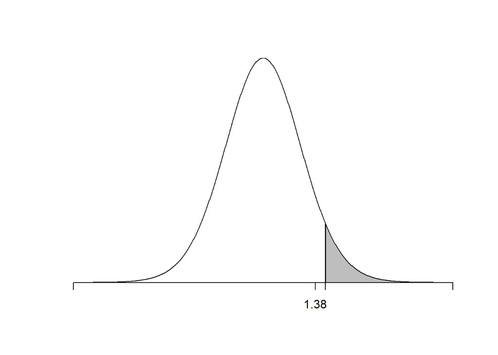

*El área gris corresponde a la región de rechazo (área a la derecha del valor crítico 1.6462604 ya que $H_1$ tiene el símbolo $>$), el estadistico de prueba o calculado 1.38323, cae en Zona de NO Rechazo*

Tomando decisión a través del valor $p$:

```r
pvalue <- pt(t_calc, df = delta, lower.tail = F)
# lower.tail = F, por que la H1 tiene el simbolo >

pvalue
```

```
[1] 0.08343956
```

Alternativa 2: utilizando la función `t.test()` del paquete base de R

```r
ttest<- t.test(x = glifo_enero$Peso, y = glifo_febrero$Peso, alternative = "greater", var.equal = F)

ttest
```

```
    Welch Two Sample t-test

data:  glifo_enero$Peso and glifo_febrero$Peso
t = 1.3832, df = 1084.1, p-value = 0.08344
alternative hypothesis: true difference in means is greater than 0
95 percent confidence interval:
 -0.00121788         Inf
sample estimates:
mean of x mean of y
 15.00238  14.99598
```

- `x`: datos de la primer muestra
- `y`: datos de la segunda muestra
- `alternative`: signo de la hipótesis alternativa, en este caso $>$: “greater”
- `var.equal`: para indicar si las varianzas son homogéneas o no.

**Aclaración:** en ninguna parte de la Alternativa 2, se especifica el $\alpha$ o nivel de significancia, ya que lo que hacemos es tomar el valor $p$ de la salida y lo comparamos con el $\alpha$ que nos indique la consigna.

5. Conclusión COMPLETA:
- Si concluyo con los valores críticos:

No existe evidencia suficiente para rechazar la $H_0$, ya que el estadístico de prueba se encuentra en la región de no rechazo, por lo tanto podemos afirmar que el peso medio de los envases en enero no fue mayor que en febrero.

- Si concluyo con el valor $p$:

No existe evidencia suficiente para rechazar la $H_0$, ya que el valor $p$ (0.0834396) es mayor al nivel de significancia ($\alpha$), por lo tanto podemos afirmar que el peso medio de los envases en enero no fue mayor que en febrero.

# Inferencia en dos medias: muestras dependientes

Si $X_1$ e $X_2$ son VA dependientes (correlacionadas), las diferencias de a pares $X_{1i} - X_{2i} = X_d$ tiene distribución

$$X_d \sim N(\mu_d, \sigma^2_d)$$

Estandarizando se obtiene:

$$t = \dfrac{\bar{X}_d - \mu_d}{\dfrac{s_d}{\sqrt{n_d}}} \sim t_{n_d-1}$$

### Intervalo de confianza

$$P \left( \bar{X_d} + t_{\alpha/2, n_d-1} \dfrac{s_d}{\sqrt{n_d}} \leq \mu_d \leq \bar{X_d} + t_{1-\alpha/2, n_d-1} \dfrac{s_d}{\sqrt{n_d}} \right) = 1 - \alpha$$

### Prueba de Hipótesis

Al ser poblaciones dependientes, las diferencias se calculan de a pares y se crea una nueva variable $X_d = X_1 - X_2$.

**Hipótesis posibles:**

$$H_0: \mu_d = 0 \quad \text{vs} \quad H_1: \mu_d \ne 0 \\
H_0: \mu_d \ge 0 \quad \text{vs} \quad H_1: \mu_d < 0 \\
H_0: \mu_d \le 0 \quad \text{vs} \quad H_1: \mu_d > 0$$

**Estadístico de prueba:**

$$t = \dfrac{\bar{X}_d - \mu_d}{\dfrac{s_d}{\sqrt{n_d}}} \sim t_{n_d-1}$$

# Ejercicio 4

Continuando con el ejercicio 2 de la Guía de Clase de TP5.

La resistencia mecánica a la penetración (RP) es una propiedad del suelo que influye sobre el desarrollo del sistema radical. Se había realizado un muestreo con un penetrómetro de campo. Los datos se encuentran en el archivo `penetrometro.xlsx`, donde RP es la resistencia a la penetración expresada en MPa (megapascales). Luego de la labranza que realiza normalmente, se tomaron datos de RP en los mismos lugares que se había tomando (respetando las ubicaciones mediante puntos de GPS), los datos se encuentran en el archivo `penetrometro2.xlsx`.

**Responder:**

1. ¿Cuál es la estimación puntual de la diferencia de la resistencia a la penetración media antes y después de la labranza?
2. ¿Cuáles son los límites de confianza del 95% de la diferencia de la resistencia a la penetración media antes y después de la labranza?
3. ¿Hay evidencias suficientes para decir que la labranza mejoró los valores de compactación, es decir que los valores luego de la labranza son menores a los valores que había antes? Utilice un nivel de significancia de 0.05.

Importamos los datos:

```r
library(readxl)
RP_antes <- read_xlsx("penetrometro.xlsx")
RP_despues <- read_xlsx("penetrometro2.xlsx")
```

Las muestras se encuentran apareadas o relacionadas ya que las medidas de RP, fueron tomadas antes y después en los mismos puntos del suelo. Por lo tanto se no se trabajarán con 2000 datos sino con 1000 pares de datos.

## Item (a).

**¿Cuál es la estimación puntual de la diferencia de la resistencia a la penetración media antes y después de la labranza?**

```r
d <- RP_antes$RP - RP_despues$RP
dbar <- mean(d)
dbar
```

```
[1] 0.00801
```

*Respuesta:* La estimación puntual de la diferencia la resistencia a la penetración media antes y después de la labranza es de 0.01 cm.

## Item (b).

**¿Cuáles son los límites de confianza del 95% de la diferencia de la resistencia a la penetración media antes y después de la labranza?**

Queremos obtener:

$P(LI \le \mu_\text{antes} - \mu_\text{después} \le LS)=95\text{%}$

o $P(LI \le \mu_d \le LS)=95\text{%}$,

donde LI: límite inferior y LS: límite superior.

Alternativa 1: A partir de la nueva variable “diferencia de a pares” obtenemos media, desvio y la cantidad de pares:

```r
# Diferencia media
dbar
```

```
[1] 0.00801
```

```r
# desvio diferencias
s_d <- sd(d)
s_d
```

```
[1] 0.03045764
```

```r
# Numero de pares
n_d <- length(d)

# Cuantiles distribución t con $n_d -1$ grados de libertad
alfa <- 0.05          # 1 - 0.95 = 0.05
t_crit <- qt(c(alfa/2, 1-alfa/2), df = n_d -1)

# error estándar
error <- s_d/sqrt(n_d)

# Margen de error: valor crítico * error estándar
ME <- t_crit * error

# Limites
IC <- dbar + ME
IC
```

```
[1] 0.006119961 0.009900039
```

Alternativa 2: utilizando la función `t.test()` del paquete base de R

```r
ttest<- t.test(x = RP_antes$RP, y = RP_despues$RP, alternative = "two", paired = T)

ttest
```

```
    Paired t-test

data:  RP_antes$RP and RP_despues$RP
t = 8.3164, df = 999, p-value = 2.944e-16
alternative hypothesis: true difference in means is not equal to 0
95 percent confidence interval:
 0.006119961 0.009900039
sample estimates:
mean of the differences
                0.00801
```

- `x`: son los datos con los cuales haremos inferencia
- `alternative`: para IC siempre es “two”, que significa a ambos lados de la curva
- **`paired`**: indica que las muestras ingresadas son apareadas (por defecto es F o FALSE, entonces hay que indicar T o TRUE)
- `conf.level`: indica el nivel de confianza (NO significancia), por defecto el 0.95 (o 95%)

*Respuesta:* De ambas maneras podemos observar que el Límite Inferior es de 0.00612 Mpa y el Límite Superior es de 0.0099 MPa del Intervalo de Confianza del 95% de la diferencia de la resistencia a la penetración media antes y después de la labranza.

$$P(0.00612 \le \mu_d \le 0.0099)=95\text{%}$$

## Item (c).

**¿Hay evidencias suficientes para decir que la labranza mejoró los valores de compactación, es decir que los valores luego de la labranza son menores a los valores que había antes? Utilice un nivel de significancia de 0.05.**

*Seguiremos los pasos de una PH:*

1. Definir las hipótesis

$H_0: \mu_\text{antes} \le \mu_\text{después} \\ H_1: \mu_\text{antes} > \mu_\text{después}$

Otra forma:

$H_0: \mu_d \le 0 \\ H_0: \mu_d > 0$

*Tener en cuenta el orden al plantear las hipótesis: primero “antes” y luego “después”.*

2. Determinar el valor del estadístico de prueba

El estadístico de prueba es: $t = \dfrac{\bar{X}_d - \mu_d}{\dfrac{s_d}{\sqrt{n_d}}}$

```r
t_calc <- dbar / (s_d/sqrt(n_d))
t_calc
```

```
[1] 8.316418
```

3. Determinar de la distribución muestral que se utilizará para la prueba de hipótesis

Continuaremos con la Distribución “t”, dado que el desvio poblacional $\sigma$ es desconocido, utilizaremos su mejor estimador $S$.

$$t \sim t_{n_d-1}$$

4. Identificación de un valor $p$ y/o el(los) valor(es) crítico(s)

En función de la distribución determinada en el paso anterior, buscaremos el valor crítico (uno sólo), ya que es una prueba **unilateral** como lo determina la $H_1$ con el símbolo $>$.

Alternativa 1: calculando por separado las partes de una PH

Tomando decisión a través de los valores críticos:

```r
alfa <- 0.05
t_crit <- qt(p = alfa, df = n_d-1, lower.tail = FALSE)
# lower.tail = FALSE porque H1 tiene simbolo >
# alfa NO se divide por dos porque la prueba es unilateral

t_crit
```

```
[1] 1.64638
```

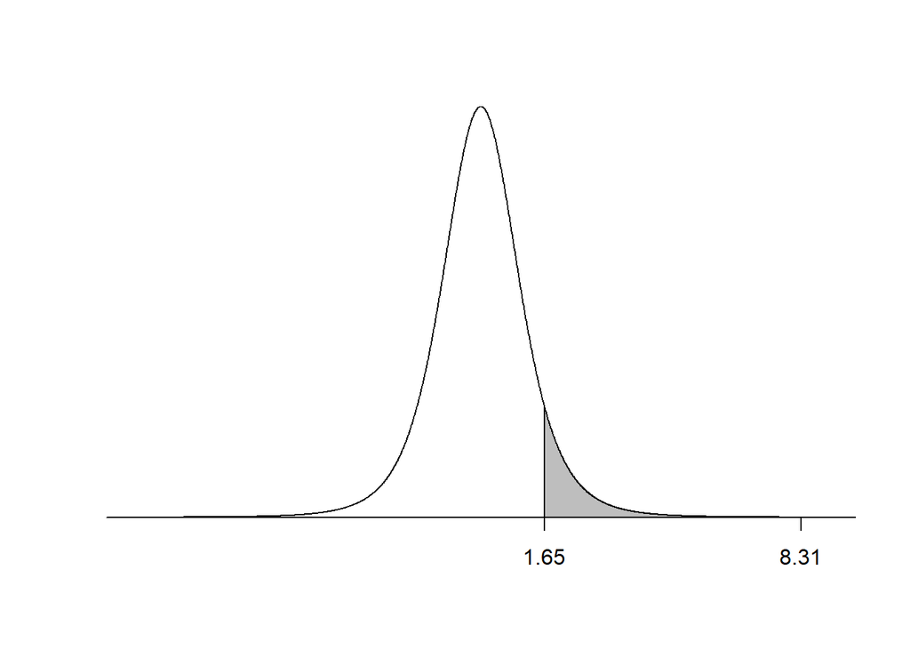

*Región de rechazo: a la derecha de 1.6463803 (a la derecha por el simbolo $>$ en $H_1$), área de color gris. El estadístico de prueba 8.3164184 cae en Región de Rechazo*

Tomando decisión a través del valor $p$:

```r
pvalue <- pt(t_calc, df = n_d-1, lower.tail = F)
# lower.tail = FALSE porque H1 tiene simbolo >

pvalue
```

```
[1] 1.471966e-16
```

*Esto significa que el área bajo la curva a la derecha del estadístico de prueba t = 8.3164184 es de 1.471966310^{-16}*

Alternativa 2: utilizando la función `t.test()` del paquete base de R

```r
ttest<- t.test(x = RP_antes$RP, y = RP_despues$RP, alternative = "greater", paired = T)

ttest
```

```
    Paired t-test

data:  RP_antes$RP and RP_despues$RP
t = 8.3164, df = 999, p-value < 2.2e-16
alternative hypothesis: true difference in means is greater than 0
95 percent confidence interval:
 0.006424281         Inf
sample estimates:
mean of the differences
                0.00801
```

- `x`: son los datos con los cuales haremos inferencia
- `alternative`: en PH lo determina el signo de $H_1$
- **`paired`**: indica que las muestras ingresadas son apareadas (por defecto es F o FALSE, entonces hay que indicar T o TRUE)
- `conf.level`: indica el nivel de confianza (NO significancia)

**Aclaración**: en ninguna parte de la Alternativa 2, se especifica el $\alpha$ o nivel de significancia, ya que lo que hacemos es tomar el valor $p$ de la salida y lo comparamos con el $\alpha$ que nos indique la consigna

5. Conclusión COMPLETA:
- Si concluyo con los valores críticos:

Existe evidencia suficiente para rechazar la $H_0$, ya que el estadístico de prueba se encuentra en la región de rechazo, por lo tanto por lo tanto podemos decir que fue efectiva la labranza, los valores de RP antes eran mayores que luego de la misma.

- Si concluyo con el valor $p$:

Existe evidencia suficiente para rechazar la $H_0$, ya que el valor $p$ (1.471966310^{-16}) es menor al nivel de significancia $\alpha$, por lo tanto podemos decir que fue efectiva la labranza, los valores de RP antes eran mayores que luego de la misma.

# Inferencia en dos varianzas o desviaciones estándar

Interesa estimar $\sigma^2_1/\sigma^2_2$

Las muestras se extraen de **dos poblaciones normales independientes**

Estadístico $F$:

$$F = \dfrac{s^2_1/\sigma^2_1}{s^2_2/\sigma^2_2} = \dfrac{s^2_1/s^2_2}{\sigma^2_1/\sigma^2_2} \sim F_{n_1-1, n_2-1}$$

Cada una de las dos poblaciones debe estar distribuida normalmente, independientemente del tamaño de la muestra. La prueba F no es robusta contra desviaciones de la normalidad. Por lo tanto, funciona mal si una o ambas poblaciones tienen una distribución que no es normal. El requisito de distribuciones normales es bastante estricto para esta prueba F.

### Intervalo de confianza

$$P \left( s^2_1/s^2_2 * F_{\alpha/2, n_1-1, n_2-1} \leq \sigma^2_1 / \sigma^2_2 \leq s^2_1/s^2_2 * F_{1-\alpha/2, n_1-1, n_2-1} \right) = 1 - \alpha$$

### Prueba de Hipótesis

**Hipótesis posibles:**

$$H_0: \sigma^2_1 = \sigma^2_2 \quad \text{vs} \quad H_1: \sigma^2_1 \ne \sigma^2_2 \\
H_0: \sigma^2_1 \ge \sigma^2_2 \quad \text{vs} \quad H_1: \sigma^2_1 < \sigma^2_2 \\
H_1: \sigma^2_1 \le \sigma^2_2 \quad \text{vs} \quad H_1: \sigma^2_1 > \sigma^2_2 \\$$

El cociente de dos varianzas se estima por el cociente estre sus varianzas muestrales qure tiene un distribución $F$

$$\dfrac{s^2_1}{s^2_2} \sim F_{n_1-1, n_2-1}$$

# Ejercicio 5

Continuando con los ejercicios 2 y 3 de esta Guía (ejercicio 4 de la Guía de Clase de TP5).

**Responder:**

1. ¿Cuál es la estimación puntual del cociente de la desviación del peso de empaque del herbicida de los dos meses analizados?
2. ¿Cuáles son los límites de confianza del 99% del cociente de la desviación del peso de empaque del herbicida de los dos meses analizados?
3. ¿Existe evidencia que indique que la variación fue similar en ambos meses?. Utilice un nivel de significancia de 0.05. *(Esta inferencia es la que nos determina como deberíamos continuar en los ejercicios 2 y 3)*

Importamos los datos:

```r
library(readxl)
glifo_febrero <- read_xlsx("glifosato.xlsx")
glifo_enero <- read_xlsx("glifosato2.xlsx")
```

*Respetar el orden de las muestras, por ejemplo, primero “enero” y luego “febrero”.*

## Item (a).

**¿Cuál es la estimación puntual del cociente de la desviación del peso de empaque del herbicida de los dos meses analizados?**

El mejor estimador del desvío poblacional $\sigma$ es el desío muestral $S$

```r
s_ene <- sd(glifo_enero$Peso)
s_feb <- sd(glifo_febrero$Peso)

s_ene/s_feb
```

```
[1] 1.020968
```

La estimación puntual del cociente de los desvios de pesos de los envases de enero y febrero es de 1.021 kg.

## Item (b).

**¿Cuáles son los límites de confianza del 99% del cociente de la desviación del peso de empaque del herbicida de los dos meses analizados?**

Queremos obtener: $P(LI \le \frac{\sigma_\text{enero}}{\sigma_\text{febrero}} \le LS) = 99\text{%}$, donde LI: límite inferior y LS: límite superior.

Alternativa 1:

```r
# Datos
n_ene <- length(glifo_enero$Peso)
n_feb <- length(glifo_febrero$Peso)
alfa <- 0.01                # 1 - 0.99 = 0.01
```

Los cuantiles de la distribución $F$ para 649 y 499 grados de libertad en el numerador y denominador

```r
# Cuantiles distribución
f_crit <- qf(p = c(alfa/2,1-alfa/2), df1 = n_ene-1, df2 = n_feb-1)
f_crit
```

```
[1] 0.805847 1.244251
```

```r
# Límites (raiz cuadrada al cociente de varianzas)
IC <- sqrt((s_ene**2/s_feb**2) * f_crit)
IC
```

```
[1] 0.9165127 1.1388492
```

Alternativa 2: utilizando la función `var.test()` del paquete base de R

```r
vartest <- var.test(x = glifo_enero$Peso, y = glifo_febrero$Peso, alternative = "two", conf.level = 0.99)
vartest
```

```
    F test to compare two variances

data:  glifo_enero$Peso and glifo_febrero$Peso
F = 1.0424, num df = 649, denom df = 499, p-value = 0.6252
alternative hypothesis: true ratio of variances is not equal to 1
99 percent confidence interval:
 0.8377538 1.2935160
sample estimates:
ratio of variances
          1.042376
```

```r
# Raíz cuadrada al resultado de IC
LI <- sqrt(0.8377538)
LI
```

```
[1] 0.9152889
```

```r
LS <- sqrt(1.2935160)
LS
```

```
[1] 1.137328
```

- `x`: son los datos de una muestra
- `y`: son los datos de la otra muestra
- `alternative`: para buscar IC siempre es“two”, que significa a ambos lados de la curva
- `conf.level`: indica el nivel de confianza (NO significancia), por defecto el 0.95 (o 95%)

*Respuesta:* Podemos observar que el Límite Inferior es de 0.917 kg y el Límite Superior es de 1.139 kg del Intervalo de Confianza del 99% del cociente de la desviación del peso de empaque del herbicida de los dos meses analizados.

## Item (c).

**¿Existe evidencia que indique que la variación fue similar en ambos meses?. Utilice un nivel de significancia de 0.05.**

> Esta inferencia es la que nos determina como deberíamos haber continuado en los ejercicios 2 y 3 de esta Guía

*Seguiremos los pasos de una PH:*

1. Definir las hipótesis

$H_0: \sigma_\text{enero} = \sigma_\text{febrero} \\ H_1: \frac{\sigma_\text{enero}}{\sigma_\text{febrero}} \ne 1$

Otra forma:

$\frac{\sigma_\text{enero}}{\sigma_\text{febrero}} = 1 \\ \sigma_\text{enero} \ne \sigma_\text{febrero}$

2. Determinar el valor del estadístico de prueba $\dfrac{s^2_1}{s^2_2}$

```r
F_calc <- s_ene^2/s_feb^2
F_calc
```

```
[1] 1.042376
```

3. Determinar la distribución muestral que se utilizará para la prueba de hipótesis

El estadístico de prueba es: El cociente de dos varianzas se estima por el cociente estre sus varianzas muestrales qure tiene un distribución $F$

$$\dfrac{s^2_1}{s^2_2} \sim F_{n_1-1, n_2-1}$$

4. Identificación de un valor $p$ y/o el(los) valor(es) crítico(s)

Alternativa 1: calculando por separado las partes de una PH

Tomando decisión a través de los valores críticos:

```r
alfa <- 0.05

F_crit <- qf(p = c(alfa/2, 1-alfa/2), df1 = n_ene-1, df2 = n_feb-1)
F_crit
```

```
[1] 0.8484917 1.1806933
```

[figure not shown]

_Región de rechazo: a los extremos de los valores críticos (ya que es una prueba bilateral, simbolo $\ne$ en $H_1$), área de color gris. El estadístico de prueba, 1.042376 cae en Región de NO Rechazo.__

Tomando decisión a través del valor $p$:

```r
# valor p
pvalue <- pf(q = F_calc, df1 = n_ene-1, df2 = n_feb-1, lower.tail = F) * 2
pvalue
```

```
[1] 0.6251543
```

*En la función `pf()` siempre que sea una prueba bilateral se trabaja con la cola superior (`lower.tail = F`) y luego se multiplica por 2.*

Alternativa 2: utilizando la función `var.test()` del paquete base de R

```r
vartest <- var.test(x = glifo_enero$Peso, y = glifo_febrero$Peso, alternative = "two")
vartest
```

```
    F test to compare two variances

data:  glifo_enero$Peso and glifo_febrero$Peso
F = 1.0424, num df = 649, denom df = 499, p-value = 0.6252
alternative hypothesis: true ratio of variances is not equal to 1
95 percent confidence interval:
 0.8828508 1.2285046
sample estimates:
ratio of variances
          1.042376
```

- `x`: son los datos de una muestra
- `y`: son los datos de la otra muestra
- `alternative`: depende el signo de $H_1$, si es bilateral: “two”, que significa a ambos lados de la curva
5. Conclusión COMPLETA:
- Si concluyo con los valores críticos:

No existe evidencia suficiente para rechazar la $H_0$, ya que el estadístico de prueba se encuentra en la región de aceptación, por lo tanto podemos asumir que el desvío de peso de los envases en ambos meses fue similar.

- Si concluyo con el valor $p$:

> **Dado que la $H_0$ no se rechaza, se asume que $\sigma_\text{enero} = \sigma_\text{febrero}$. Por lo cual, el procedimeinto correcto para inferir en las medias fue el que se realizo en el Ejercicio 2 (donde se asumio que los desvíos poblacionales eran iguales)**

# Inferencia en dos proporciones

Por aproximación binomial, la distribución del estimador de la diferencia entre dos **proporciones** es:

$$p_1 - p_2 \sim N(\pi_1 - \pi_2, \dfrac{\bar{p}\bar{q}}{n_1} + \dfrac{\bar{p}\bar{q}}{n_2})$$

donde: $\bar{p} = \dfrac{n_1p_1 + n_2p_2}{n_1 + n_2}$ y $\bar{q} = 1 - \bar{p}$

Estandarizando:

$$Z = \dfrac{(p_1 - p_2) - (\pi_1 - \pi_2)}{\sqrt{\dfrac{\bar{p}\bar{q}}{n_1} + \dfrac{\bar{p}\bar{q}}{n_2}}} \sim N(0, 1)$$

### Intervalo de confianza

$$P((p_1 - p_2) - \sqrt{\dfrac{\bar{p}\bar{q}}{n_1} + \dfrac{\bar{p}\bar{q}}{n_2}} \le \pi_1-\pi_2 \le (p_1 - p_2) + \sqrt{\dfrac{\bar{p}\bar{q}}{n_1} + \dfrac{\bar{p}\bar{q}}{n_2}}) = 1 - \alpha$$

### Prueba de Hipótesis

**Hipótesis posibles:**

$$H_0: \pi_1 - \pi_2 = 0 \quad \text{vs} \quad H_1: \pi_1 - \pi_2 \ne 0 \\
H_0: \pi_1 - \pi_2 \ge 0 \quad \text{vs} \quad H_1: \pi_1 - \pi_2 < 0 \\
H_0: \pi_1 - \pi_2 \le 0 \quad \text{vs} \quad H_1: \pi_1 - \pi_2 > 0$$

**Estadístico de prueba:**

$$Z = \dfrac{(p_1 - p_2) - (\pi_1 - \pi_2)}{\sqrt{\bar{p}(1-\bar{p}) \left(\dfrac{1}{n_1} + \dfrac{1}{n_2} \right)}} \sim N(0, 1)$$

donde: $\bar{p} = \dfrac{n_1p_1 + n_2p_2}{n_1 + n_2}$

# Ejercicio 6

Continuando con el ejercicio 3 de la Guía de Clase de TP5.

El proveedor de un insecticida para control de barrenador del brote de soja (*Epinotia aporema*) afirma que su producto tiene una eficacia de mayor al 60%. Primero se condujo un experimento en donde se seleccionaron 950 plantas con barrenador del brote y se aplico se le aplicó la dosis de producto recomendada. Los datos se encuentran en el archivo `barrenador.xlsx`, donde “Control”, indica si el producto controló o no al barrenador. El mismo experimento se replicó en otro lote donde se seleccionaron 1100 plantas con barrenador del brote y se aplico se le aplicó la dosis de producto recomendada. Los datos se encuentran en el archivo `barrenador2.xlsx`

**Responder:**

1. ¿Cuál es la estimación puntual de la diferencia de proporción de eficacia del insecticida en ambos lotes?
2. ¿Cuáles son los límites de confianza del 95% de la diferencia de proporción de eficacia del insecticida en ambos lotes?
3. ¿Esta evidencia es suiciente para concluir la eficacia del producto fue igual en ambos lotes? Utilice un nivel de significancia de 0.05.

Importamos los datos:

```r
library(readxl)
lote1 <- read_xlsx("barrenador.xlsx")
lote2 <- read_xlsx("barrenador2.xlsx")
```

## Item (a).

**¿Cuál es la estimación puntual de la diferencia de proporción de eficacia del insecticida en ambos lotes?**

Primero determinamos cuantas muestras controló y cuantas no en ambos lotes:

```r
library(dplyr)

# lote 1
total1 <- lote1 %>%
  group_by(Control) %>%
  count()
total1
```

```
# A tibble: 2 x 2
# Groups:   Control [2]
  Control     n
  <chr>   <int>
1 no        430
2 si        520
```

```r
# lote 2
total2 <- lote2 %>%
  group_by(Control) %>%
  count()
total2
```

```
# A tibble: 2 x 2
# Groups:   Control [2]
  Control     n
  <chr>   <int>
1 no        475
2 si        625
```

Luego calculamos la proporción de plantas controladas por el producto:

```r
# lote 1
p1 <- 520/950
p1
```

```
[1] 0.5473684
```

```r
# lote 2
p2 <- 625/1100
p2
```

```
[1] 0.5681818
```

*Respuesta:* La proporción de plantas controladas por el producto en el lote 1 es de 0.5474 o 54.74% y en el lote 2 es de 0.5682 o 56.82%.

## Item (b).

**¿Cuáles son los límites de confianza del 95% de la diferencia de proporción de eficacia del insecticida en ambos lotes?**

Queremos obtener: $P(LI \le \pi_1-\pi_2 \le LS)=95\text{%}$, donde LI: límite inferior y LS: límite superior.

```r
# Datos
n1 <- 950
n2 <- 1100
alfa <- 0.05   # 1 - 0.95 = 0.05

# Cuantiles distribución Z
z_crit <- qnorm(c(alfa/2, 1-alfa/2))
z_crit
```

```
[1] -1.959964  1.959964
```

```r
# error estándar de la media
p <- (n1*p1 + n2*p2)/(n1+n2)
q <- 1-p

error <- sqrt(p*q/n1 + p*q/n2)

# Margen de error: valor crítico * error estándar
ME <- z_crit * error

# IC95%  = EP +- ME
IC <- p1 - p2 + ME
IC
```

```
[1] -0.06391963  0.02229283
```

*Respuesta:* Podemos observar que el Límite Inferior es de -0.0639196 cm y el Límite Superior es de 0.0222928 cm del Intervalo de Confianza del 95% de la verdadera diferencia de proporción de plantas controladas por el insecticida en ambos lotes.

$$P(-0.0639196 \le \pi_1-\pi_2 \le 0.0222928)=95\text{%}$$

## Item (c).

**¿Esta evidencia es suiciente para concluir la eficacia del producto fue igual en ambos lotes? Utilice un nivel de significancia de 0.05.**

*Seguiremos los pasos de una PH:*

1. Definir las hipótesis

$H_0: \pi_1 = \pi_2$

$H_1: \pi_1 \ne \pi_2$

2. Determinar el valor del estadístico de prueba

El estadístico de prueba es: $Z = \dfrac{(p_1 - p_2) - (\pi_1 - \pi_2)}{\sqrt{\bar{p}(1-\bar{p}) \left(\dfrac{1}{n_1} + \dfrac{1}{n_2} \right)}}$

donde: $\bar{p} = \dfrac{n_1p_1 + n_2p_2}{n_1 + n_2}$

```r
# Estadístico de prueba
z_calc <- (p1-p2)/sqrt(p*(1-p)/n1 + p*(1-p)/n2)
z_calc
```

```
[1] -0.9463483
```

3. Determinar la distribución muestral que se utilizará para la prueba de hipótesis

$$Z \sim N(0, 1)$$

4. Identificación de un valor $p$ y/o el(los) valor(es) crítico(s)

Alternativa 1: calculando por separado las partes de una PH

Tomando decisión a través de los valores críticos:

```r
# Valores críticos
z_crit <- qnorm(c(alfa/2, 1-alfa/2))
z_crit
```

```
[1] -1.959964  1.959964
```

[output not shown]

[output not shown]

[output not shown]

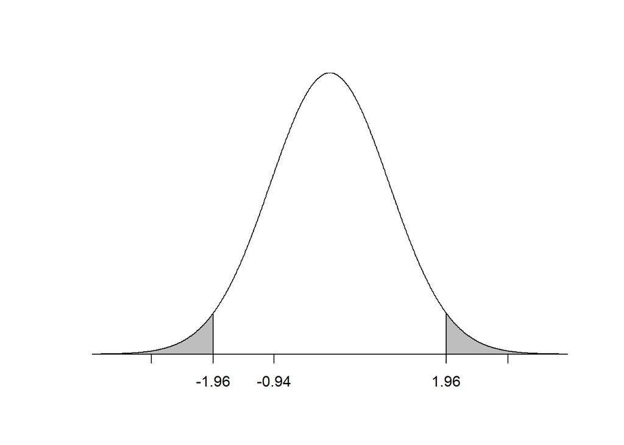

*Región de rechazo: área de color gris. El estadístico de prueba, -0.9463483 cae en Región de NO Rechazo.*

Tomando decisión a través del valor $p$:

```r
# Valor P
pvalue<- pnorm(z_calc, lower.tail = z_calc < 0) * 2

pvalue
```

```
[1] 0.343971
```

5. Conclusión COMPLETA:
- Si concluyo con los valores críticos:

No existe evidencia suficiente para rechazar la $H_0$, ya que el estadístico de prueba se encuentra en la región de no rechazo, por lo tanto podemos concluir que la eficacia del producto fue igual en ambos lotes.

- Si concluyo con el valor $p$:

No existe evidencia suficiente para rechazar la $H_0$, ya que el valor $p$ (0.343971) es mayor al nivel de significancia ($\alpha=0.05$), por lo tanto podemos concluir que la eficacia del producto fue igual en ambos lotes.

# Resumen de aclaraciones de Pruebas de Hipótesis

**Distribución normal “z” y Distribución “t” de Student:**

Argumento `p` en las funciones `qnorm()` o `qt()`, para averiguar valores críticos:

- PH unilaterales (izquierda o derecha, $H_1$ tiene símbolo $<$ o $>$ respectivamente): `p = alpha`
- PH bilateral ($H_1$ tiene el simbolo $\ne$): `p = c(alfa/2,1-alfa/2)`

Argumento `lower.tail`, en las funciones `pnorm()` o `pt()`, para averiguar valor “p”:

- PH unilateral derecha ($H_1$ tiene el símbolo $>$): `lower.tail = F`
- PH unilateral izquierda ($H_1$ tiene el símbolo $<$): `lower.tail = T`
- PH bilaterales ($H_1$ tiene símbolo $\ne$):
  - si `z_calc` o `t_calc` < 0, entonces `lower.tail = T` y luego multiplicar por 2
  - si `z_calc` o `t_calc` > 0, entonces `lower.tail = F` y luego multiplicar por 2

**Distribución $F$:**

Argumento `p` en la función `qf()`, para averiguar valores críticos:

- PH unilaterales (izquierda o derecha, $H_1$ tiene símbolo $<$ o $>$ respectivamente): `p = alpha`
- PH bilateral ($H_1$ tiene el simbolo $\ne$): `p = c(alfa/2,1-alfa/2)`

Argumento `lower.tail` en la función `pf())`, para averiguar valor “p”:

- PH unilateral derecha ($H_1$ tiene el símbolo $>$): `lower.tail = F`
- PH unilateral izquierda ($H_1$ tiene el símbolo $<$): `lower.tail = T`
- PH bilaterales ($H_1$ tiene símbolo $\ne$):
  - si $s < \sigma_0$, entonces `lower.tail = T` y luego multiplicar por 2
  - si $s > \sigma_0$, entonces `lower.tail = F` y luego multiplicar por 2

Material preparado por [Cátedra de Estadística FCA-UNL](https://github.com/estadistica-fca/)

[figure not shown]